# Yield Leaderboard

Response Surface Methods & Computer Experiments (STAT 6984)

Robert B. Gramacy (rbg@vt.edu : http://bobby.gramacy.com) Department of Statistics, Virginia Tech

## Visualizing progress

Below are four views into the progress of students searches in the [yield project](http://bobby.gramacy.com/teaching/rsm/yield.html). The goal is to maximize the yield of a a process in seven variables: concentrations of six nutrients and one additive. The process can only be observed through a Shiny app, and with noise. The noise process smoothly varies over the weeks of the experiment.

The plot below shows the best actual yield values, i.e., observed without noise, obtained by each student over the weeks of the study period.

- To make it harder to back out what the noise level in each week might be, the y-axis has been scaled so the bottom is at zero.

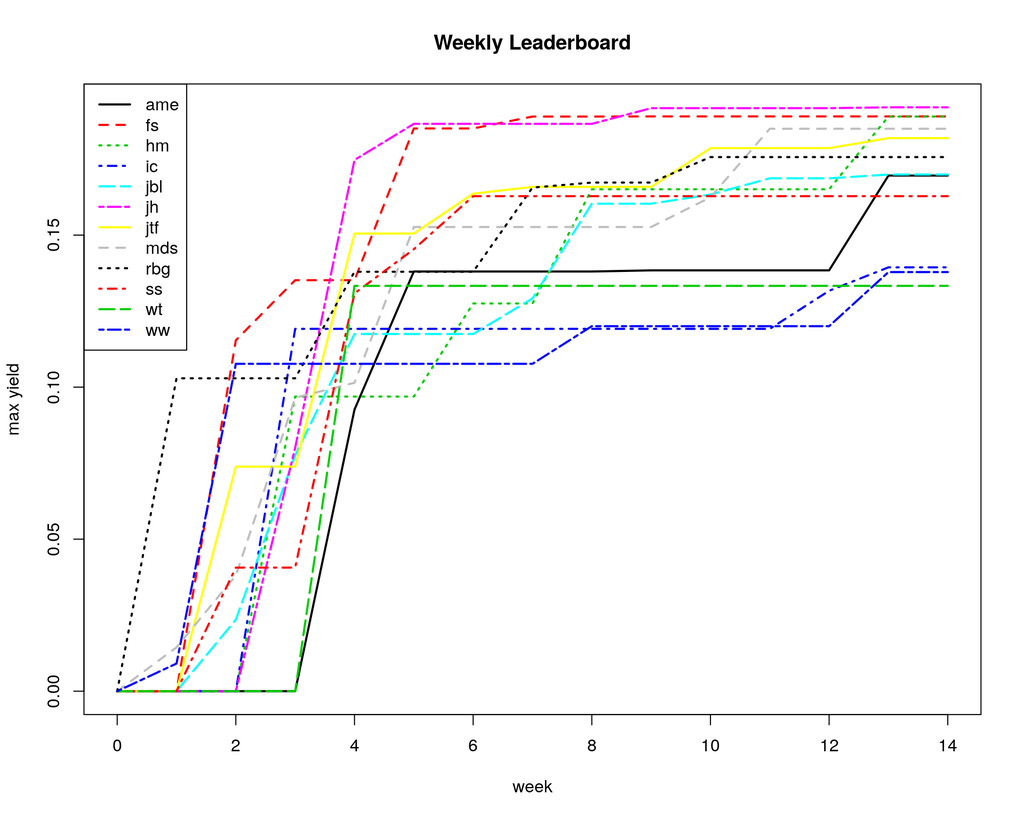

The next plot shows a raw analogue of the plot above, summarizing the actual noisy yield values stored in each student’s cache.

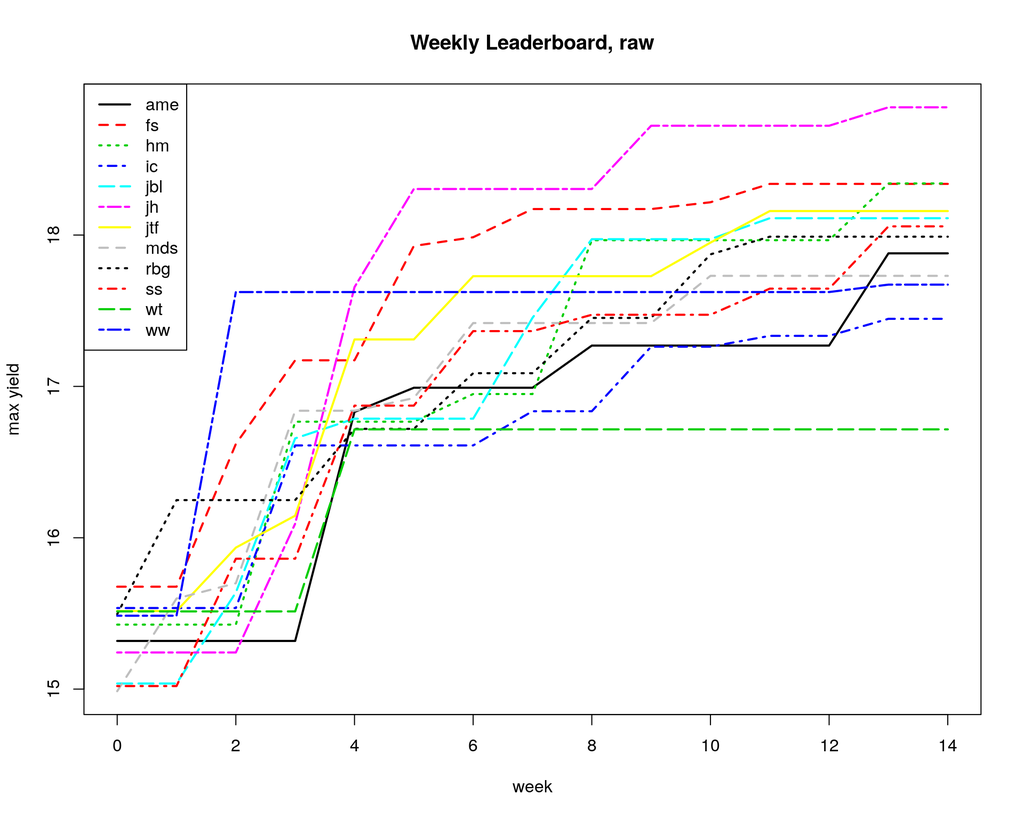

Here is a different view. The plot below shows the actual (no-noise) yield values as a function of each run performed by the student.

- Here, a “run” means a press of the “Run” button on the Shiny app.
- Again, the yield values have been scaled to obscure the true values relative to the noisy ones in other plots.

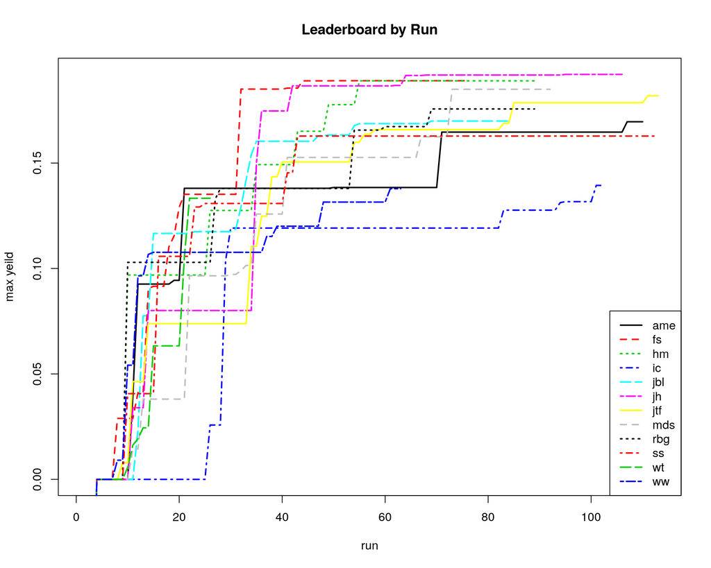

Finally, below is the noisy view into the same thing, looking at the raw yield values stored in each student’s cache.

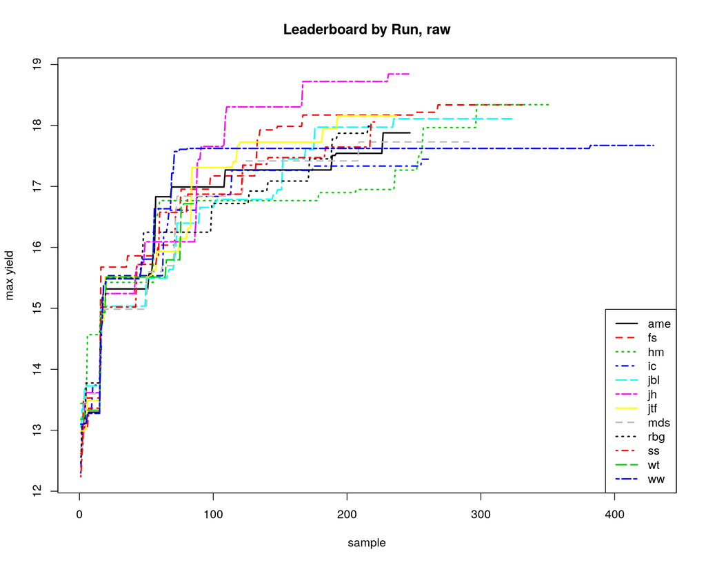